# Network Analysis of the 2004 Madrid Train Bombing

Jered Sanchez

February 5, 2019

## Madrid Terrorist Relationship Network

The analysis begins with transforming the data from the files provided into a graph object consisting of nodes and ties, in this case nodes represent terrorists in the network and ties the relationship strenghts between them.

Showing the basic attributes of the network below, we see there are 64 nodes and 243 relationships between them:

```r
# Explore the set of nodes
V(g)
```

```
## + 64/64 vertices, named, from 31c0d17:
##  [1] Jamal Zougam            Mohamed Bekkali
##  [3] Mohamed Chaoui          Vinay Kholy
##  [5] Suresh Kumar            Mohamed Chedadi
##  [7] Imad Eddin Barakat      Abdelaziz Benyaich
##  [9] Abu Abderrahame         Omar Dhegayes
## [11] Amer Azizi              Abu Musad Alsakaoui
## [13] Mohamed Atta            Ramzi Binalshibh
## [15] Mohamed Belfatmi        Said Bahaji
## [17] Galeb Kalaje            Abderrahim Zbakh
## [19] Farid Oulad Ali         José Emilio Suárez
## + ... omitted several vertices
```

```r
# Print the number of nodes

vcount(g)
```

```
## [1] 64
```

```r
# Explore the set of ties
E(g)
```

```
## + 243/243 edges from 31c0d17 (vertex names):
##  [1] Jamal Zougam--Mohamed Bekkali
##  [2] Jamal Zougam--Mohamed Chaoui
##  [3] Jamal Zougam--Vinay Kholy
##  [4] Jamal Zougam--Suresh Kumar
##  [5] Jamal Zougam--Mohamed Chedadi
##  [6] Jamal Zougam--Imad Eddin Barakat
##  [7] Jamal Zougam--Abdelaziz Benyaich
##  [8] Jamal Zougam--Abu Abderrahame
##  [9] Jamal Zougam--Amer Azizi
## [10] Jamal Zougam--Abu Musad Alsakaoui
## + ... omitted several edges
```

```r
# Print the number of ties
ecount(g)
```

```
## [1] 243
```

## Initial Data Visualization

Once we have a general idea of the data and structure of the graph, we can begin to visualize the network. This network has a typical core-periphery structure, with a densely knitted center and a sparser periphery around it.

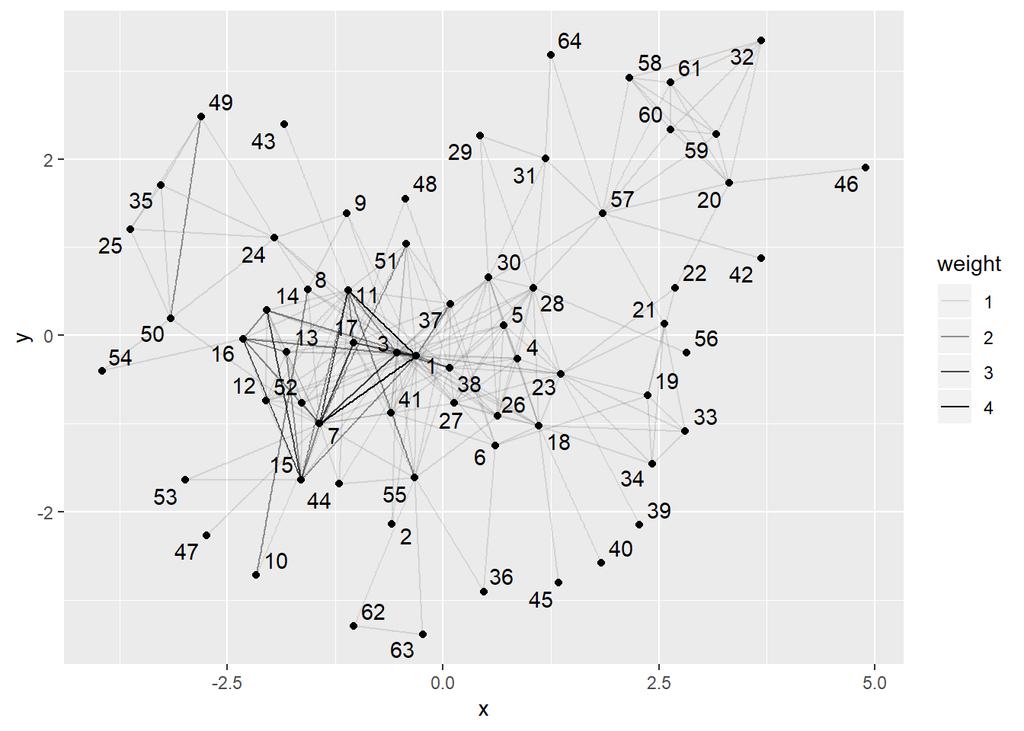

Circular network layout

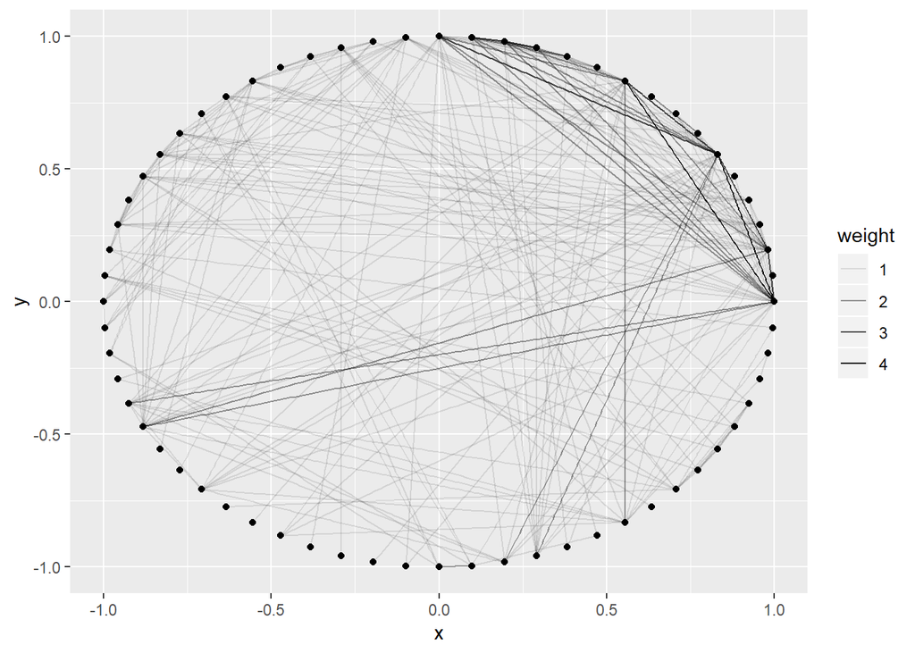

Grid network layout

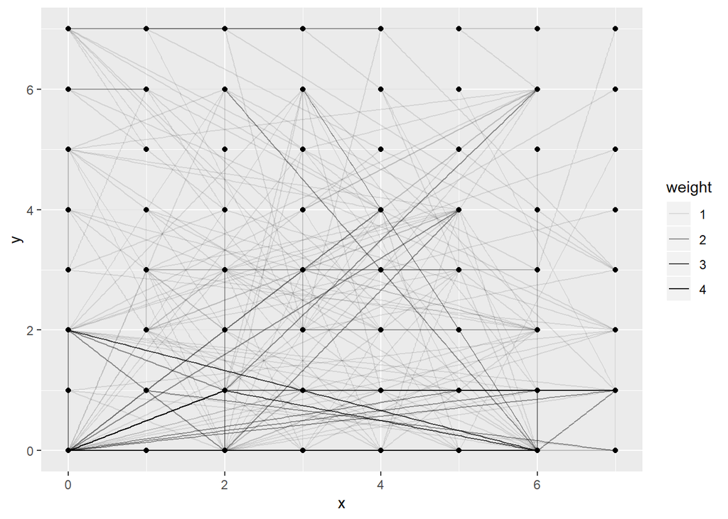

## Network Centrality Measures

We can look for the most connected terrorists of the train bombing network using degree centrality. The ranking leader, Jamal Zougam, was in fact directly involved in the bombings and was one of the first to be arrested.

```
## # A tibble: 64 x 3
##       id name               degree
##    <dbl> <chr>               <dbl>
##  1     1 Jamal Zougam           29
##  2     3 Mohamed Chaoui         27
##  3     7 Imad Eddin Barakat     22
##  4    11 Amer Azizi             18
##  5    38 Said Berrak            17
##  6    17 Galeb Kalaje           16
##  7    23 Naima Oulad Akcha      16
##  8    18 Abderrahim Zbakh       15
##  9    28 Jamal Ahmidan          14
## 10    55 Mohamed El Egipcio     13
## # ... with 54 more rows
```

Several other measures of network centrality can be helpful for analysis. In the following table tie strength, betweenness, and closeness are included.

### Tie Betweenness

Ties with high betweenness may have considerable influence within a network by virtue of their control over information passing between nodes. Removing them will most disrupt communication between nodes.

```
## # A tibble: 64 x 6
##       id name                  degree strength betweenness closeness
##    <dbl> <chr>                  <dbl>    <dbl>       <dbl>     <dbl>
##  1     3 Mohamed Chaoui            27       34       374.    0.00820
##  2     1 Jamal Zougam              29       43       264.    0.00813
##  3    38 Said Berrak               17       19       109.    0.00769
##  4    28 Jamal Ahmidan             14       14       260.    0.00752
##  5    27 S B Abdelmajid Fakhet     12       12        56.9   0.00746
##  6    37 Abdeluahid Berrak         11       12       267.    0.00746
##  7    23 Naima Oulad Akcha         16       16       234.    0.00730
##  8    18 Abderrahim Zbakh          15       15       178.    0.00725
##  9    30 Hamid Ahmidan             12       12        53.2   0.00725
## 10    55 Mohamed El Egipcio        13       14       171.    0.00709
## # ... with 54 more rows
```

## Final Data Visualization

Once we have an idea of how the network behaves, and the key targets within the network, we can search and visualize the data interactively. This feature allows us to single out a target by selecting the node itself or by the dropdown selector box. You can scoll up and down to zoom on the graph and see the node names.

[interactive chart not shown]